# Probability: **Survival Functions**

Analytical survival functions can be plotted (similar to the PDFs in Fig.7.1) as follows:

```python
import numpy as np
from scipy import stats
from matplotlib import pyplot as plt
```

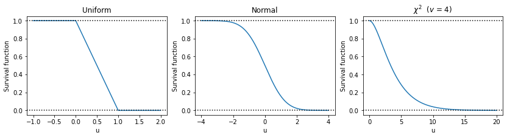

```python
# Define ranges of thresholds
u0   = np.linspace(-1, 2, 1001)  # random variable range for the uniform distribution
u1   = np.linspace(-4, 4, 1001)  # random variable range for the normal distribution
u2   = np.linspace(0, 20, 1001)  # random variable range for the chi2 distribution


# Use analytical equations to calculate the probability densities at all x values
sf0  = stats.uniform.sf(u0)     # SF for a uniform random variable
sf1  = stats.norm.sf(u1)        # SF for a normal random variable
sf2  = stats.chi2.sf(u2, 4)     # SF for a chi2 random variable (with degrees of freedom = 4)


# Plot the survival functions
fig,ax = plt.subplots(1, 3, figsize=(14,3))

ax[0].plot(u0, sf0)
ax[1].plot(u1, sf1)
ax[2].plot(u2, sf2)

ax[0].set_title('Uniform')
ax[1].set_title('Normal')
ax[2].set_title('$\chi^2$  ($v$ = 4)')

plt.setp(ax, xlabel='u')
plt.setp(ax, ylabel='Survival function')

[axx.axhline(0, color='k', linestyle=':')  for axx in ax]
[axx.axhline(1, color='k', linestyle=':')  for axx in ax]

plt.show()
```

**Figure 7.2**: Survival functions for three types of random variables. $u$ = threshold. $\nu$ = degrees of freedom.

From these plots the probability $P(x>u)$ is a somewhat clearer. For example, it is much clearer that $P(x>2.0)$ is close to zero for the normal distribution.

## Numerically verifying survival functions

Analytical survival functions can be numerically verified in Python as demonstrated below.

**Note**: only the unform survival function is verified below. As an exercise, you may wish to numerically verify the survival functions for the normal and $\chi^2$ distributions.

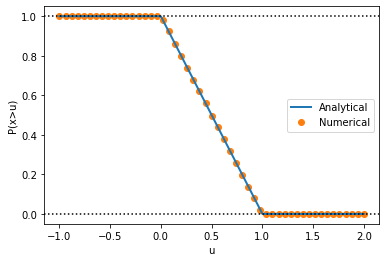

```python
x0   = np.random.rand(10000)   # random values from the uniform distribution
u0n  = np.linspace(-1, 2, 51)  # thresholds for numerical survival function calculations
sf0n = [(x0>uu).mean()  for uu in u0n]  # numerical survival function calculations


# plot the analytical and numerical survival functions:
plt.figure()
ax = plt.axes()
ax.plot(u0, sf0, linewidth=2, zorder=1, label='Analytical')
ax.plot(u0n, sf0n, 'o', zorder=0, label='Numerical')
ax.axhline(0, color='k', linestyle=':')
ax.axhline(1, color='k', linestyle=':')
ax.legend()
ax.set_xlabel('u')
ax.set_ylabel('P(x>u)')
plt.show()
```

**Figure 7.3**: Numerical verification of the survival function for the uniform distribution.

Note that the numerical survival function is nearly identical to the analytical one.

Up to and including this notebook, we have considered only relatively simple random variables --- those from the uniform, normal and $\chi^2$ distributions. How about more complex random variables, like combinations of multiple random variables? For example, if $x$ is a random variable whose values follow the normal distribution, what distribution would the variable $x^2$ follow? The next notebook considers this question.